# Animation in R

Tadesse Habte

I have seen animation of plots on YouTube and some other websites and wondered If this can be achieved using R. I finally got introduced to [gganmiate](https://gganimate.com/) and [animate](https://yihui.org/animation/) ! I will produce couple of animation and explain what I learned.

Good visualization, like animation, gives good impression but more importantly it should be engaging and ensure  
audience understand the message.

To create animation of plots, after you prepare your data, you are creating many plots(depends on your query and data size)  
and join or sew these frames together. You remember those [Flip Book Animation](https://www.youtube.com/watch?v=Njl-uqnmBGA)? Exactly!

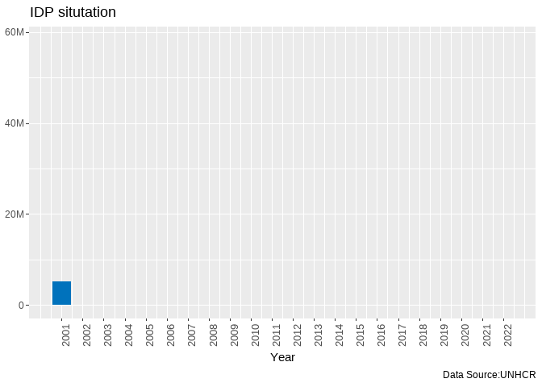

[Getting Started](https://cran.r-project.org/web/packages/gganimate/vignettes/gganimate.html)

## Animation of bar chart

Let’s create animation of bar chart. First let’s get sample and see what our dataframe looks like, couple of rows will be enough to show.

| Year | CountryOriginName | CountryAsylumName | REF | ASY | OIP | IDP | STA | OOC | HCO | UNHCRBureau |
| --- | --- | --- | --- | --- | --- | --- | --- | --- | --- | --- |
| 2017 | Democratic People's Republic of Korea | Australia | 19 | 5 | 0 | 0 | 0 | 0 | 0 | Asia |
| 2020 | Libya | Cyprus | 12 | 5 | 0 | 0 | 0 | 0 | 0 | Europe |
| 1971 | Various / unknown | Zambia | 50 | 0 | 0 | 0 | 0 | 0 | 0 | EastAfrica |
| 2002 | Oman | USA | 7 | 0 | 0 | 0 | 0 | 0 | 0 | Americas |
| 2017 | Eritrea | Sudan | 108243 | 4901 | 0 | 0 | 0 | 71 | 0 | EastAfrica |

Let’s get ranked dataframe, top 10 countries for each year.

```r
refugee_ranked <-population%>%
  filter(Year>1979)%>%
  group_by(Year,CountryOriginName)%>%
  summarise(Tot=sum(REF+ASY))%>%
 #min_rank is alternative function  but there will be no ties, the same in the rank :) and by multiplying by 1,we should get non integer rank
  mutate(rank = rank(-Tot) * 1) %>%
  filter(rank <=10)#%>% # Do you want to the top 10 countries ?
  #ungroup()
```

The idea is to create animation of top 10 nationalities(Refugee or Asylum-seekers) from 1980 to 2021, 41 years. To achieve this: you first create simple static plots based on their rank. Technically speaking,you create plots from year 1980 to 2021, as plots or frames. Then the next step is to apply the [transition states](https://gganimate.com/reference/transition_states.html) that applies the transition between several distinct stages(the year in our case) of the our data like [Flip Book Animation](https://www.youtube.com/watch?v=Njl-uqnmBGA).  
When we go to our project, we then need to create the ggplot and add [transition state](https://gganimate.com/reference/transition_states.html).

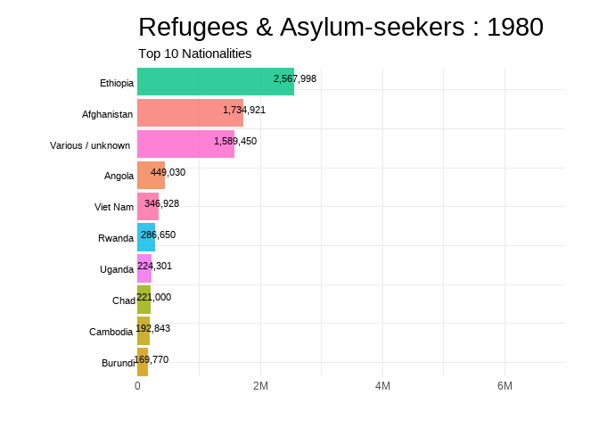

Data source : unhcrdatapackage

```r
plt_displacement<-ggplot(refugee_ranked,
  aes(rank, group = CountryOriginName, #'group' helps to track frames
                     fill = as.factor(CountryOriginName))) +
    geom_tile(aes(y = Tot/2,height = Tot,width = 0.9), alpha = 0.8, color = NA) +
  # Make some space : paste(CountryOriginName, " ")
  geom_text(aes(y = 0, label = paste(CountryOriginName, " ")), vjust = 0.6, hjust = 1.1,size=3) +
  # geom_text(aes(y=Tot,label = label_number(scale_cut = cut_short_scale())),vjust=0,size=3)+# test
  geom_text(aes(y=Tot,label = format(Tot, big.mark = ",", scientific = FALSE)),vjust=0,size=3)+
  coord_flip(clip = "off", expand = FALSE) +
  scale_y_continuous(labels = scales::label_number_si())+
  scale_x_reverse() +
  guides(color = FALSE, fill = FALSE) + #  set scale-by-scale guide off , there is not need for legend
  labs(title = 'Refugees & Asylum-seekers : {closest_state}',  # similar like faceting by time (year). Helps to indicates what each point is related to.
        subtitle  =  "Top 10 Nationalities")+
  theme_minimal() +
  theme(plot.title = element_text(hjust = 0, size = 22),
        axis.ticks.y  = element_blank(),axis.text.y  = element_blank(),axis.title.y = element_blank(),axis.title.x =element_blank(),plot.margin = margin(0.5,1,1,4, "cm")
        #plot.margin = margin(2,2, 2, 4, "cm")
        ) +
  transition_states(Year, transition_length = 4, state_length = 1) +
  ease_aes('cubic-in-out')# ease_aes() aesthetic helps to control the rate of change between the transition states
  # You can adjust the animation settings
animate(plt_displacement, fps = 4, # frames per second,
      # width = 1200,height = 1000,
       renderer = gifski_renderer("plt_displacement.gif")# gifski_renderer() takes list of images & construct them into an animation
       #, end_pause = 15, start_pause =  15s
       )
```

```r
#You want to save animations? Use anim_save()
# anim_save("plt_displacement.gif", plt_displacement)
```

## Animation of line chart

Line chart animation is not different from the others. After building the chart add aesthetics **transition_…()** that will give variable to your frame .

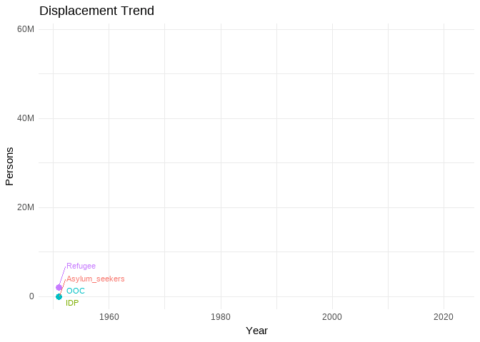

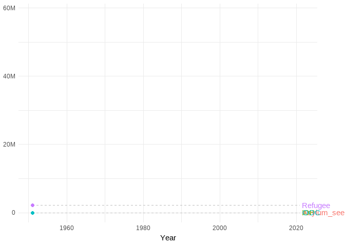

## Animation and map

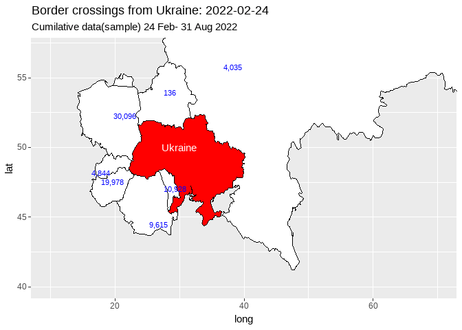

Data source: [UNHCR](https://data.unhcr.org/en/situations/ukraine)